# Tree Based Methods

# 6 Boosting

Like bagging, boosting is a general approach that can be applied to many statistical learning methods for regression or classification, but we will only discuss boosting for decision trees. Recall that bagging involves creating multiple copies of the original training data set using the bootstrap, fitting a separate decision tree to each copy, and then combining all of the trees in order to create a single predictive model. Notably, each tree is built on a bootstrap data set, independent of the other trees. *Boosting* works in a similar way except that the trees are grown sequentially, each tree is grown using information from previously grown trees. (More specific instructions can be found in the book). Unlike fitting a single large decision tree to the data, which amounts to fitting the data hard and potentially overfitting, the boosting approach learns slowly. Given the current model, we fit a decision tree to the residuals from the model. We then add this new decision tree into the fitted function in order to update the residuals. Each of these trees can be rather small, with just a few terminal nodes, determined by the parameter in the algorithm. By fitting small trees to the residuals, we slowly improve the function in areas where it was not performing well. The shrinkage parameter *lambda* slows the process down even further, allowing more an different shaped trees to attack the residuals. The package `gbm` (gradient boosted models) handles a variety of regression and classification problems.

## 6.1 Tuning parameters for boosting

**The number of trees B.** Unlike bagging and random forest, boosting can overfit if B is too large, although this overfitting tends to occur slowly if at all. We use cross validation to select B.

**The shrinkage parameter lambda**, a small, positive number. This controls the rate at which boosting learns. Typical values are 0.01 or 0.001, and the right choice can depend on the problem. Very small lambda can require using a very large value of B in order to achieve performance.

**The number of splits** d in each tree, which controls the complexity of the boosted ensemble. Often d=1 works well, in which each tree is a *stump*, consisting of a single split and resulting in an additive model. More generally d is the interaction depth, and controls the interaction order of the boosted model, since d splits can involve at most d variables. So with d=1 no interaction between parameters is allowed, and d=2 is a pairwise interaction.

Regression with Boosting

Here we use the `gbm` package, and within it the `gbm()` function, to fit boosted regression trees to the `Boston` data set. We run `gbm()` with the option `distribution = "gaussian"` since this is a regression problem; if it were a binary classification problem, we would use `distribution = "bernoulli"`. The argument `n.trees = 5000` indicates that we want $5000$ trees, and the option `interaction.depth = 4` limits the depth of each tree.

Example of use: Train a gradient boosting model for regression gbm_model <- gbm( formula = medv ~ ., # The model formula data = train_boston, # Training data distribution = “gaussian”, # Loss function for regression (gaussian for squared error) n.trees = 100, # Number of trees to build interaction.depth = 3, # Maximum depth of each tree shrinkage = 0.01, # Learning rate (step size reduction) n.minobsinnode = 10, # Minimum number of observations in the terminal nodes cv.folds = 5 # Number of cross-validation folds for evaluation )

```r
set.seed(42)
boost.boston <- gbm(
  medv ~ .,
  data = Boston[train, ],
  distribution = "gaussian",
  n.trees = 5000,
  interaction.depth = 4)
```

The `summary()` function produces a relative influence plot and also outputs the relative influence statistics.

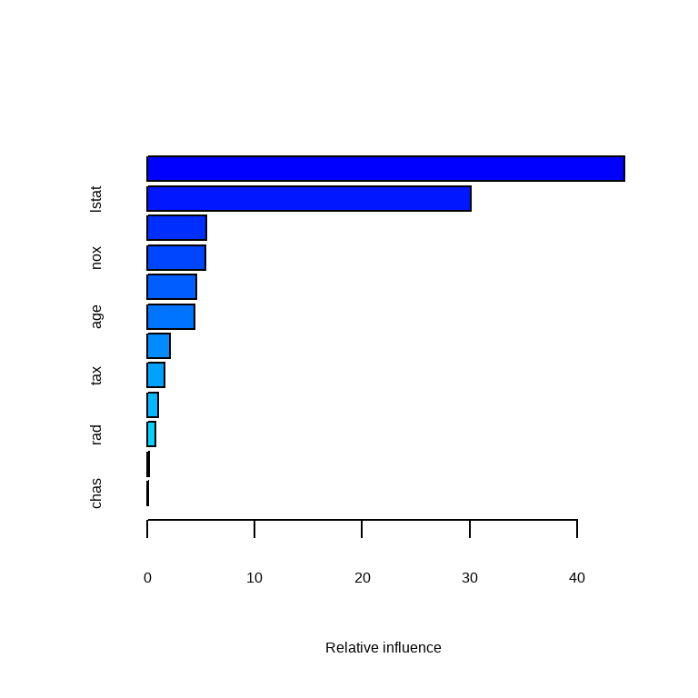

```
            var     rel.inf
rm           rm 44.40567454
lstat     lstat 30.10922797
crim       crim  5.51512326
nox         nox  5.40206684
dis         dis  4.51780767
age         age  4.35951069
ptratio ptratio  2.09717861
tax         tax  1.60055211
indus     indus  1.03276811
rad         rad  0.78491069
zn           zn  0.14283068
chas       chas  0.03234884
```

```r
summary(boost.boston)
```

We see that `lstat` and `rm` are by far the most important variables. We can also produce *partial dependence plots* for these two variables. These plots illustrate the marginal effect of the selected variables on the response after *integrating* out the other variables. In this case, as we might expect, median house prices are increasing with `rm` and decreasing with `lstat`.

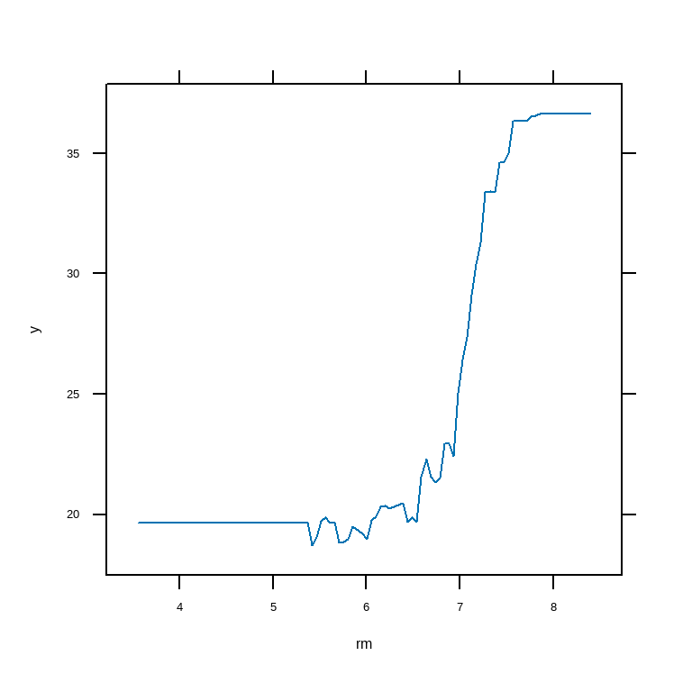

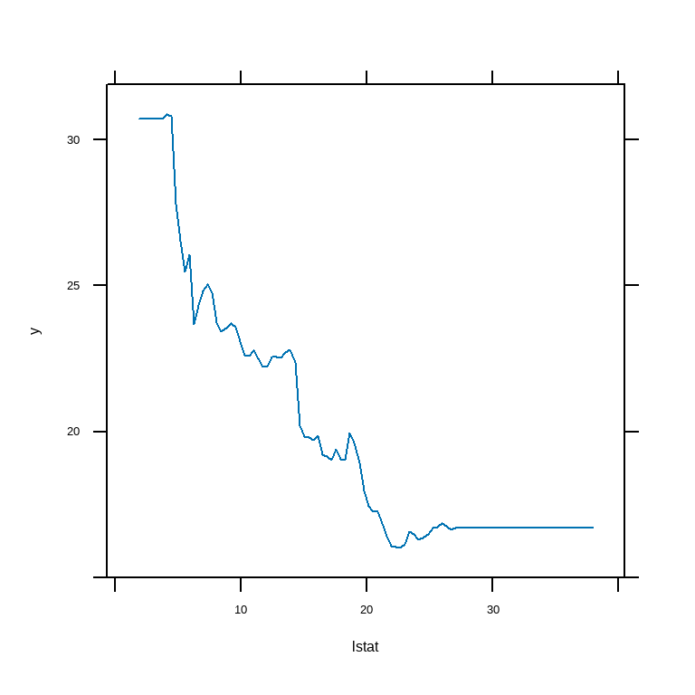

```r
plot(boost.boston, i = "rm")
plot(boost.boston, i = "lstat")
```

We now use the boosted model to predict `medv` on the test set:

```r
yhat.boost <- predict(boost.boston,
    newdata = Boston[-train, ], n.trees = 5000)
mean((yhat.boost - boston.test)^2)
```

```
[1] 17.55734
```

```r
boost.boston <- gbm(medv ~ ., data = Boston[train, ],
    distribution = "gaussian", n.trees = 5000,
    interaction.depth = 4, shrinkage = 0.2, verbose = F)
yhat.boost <- predict(boost.boston,
    newdata = Boston[-train, ], n.trees = 5000)
mean((yhat.boost - boston.test)^2)
```

```
[1] 17.1414
```

In this case, using $\lambda=0.2$ leads to a lower test MSE than $\lambda=0.001$.

We will have to use cross validation to select the best parameters for the *number of trees*, the *depth tuning parameter* and *shrinkage parameter* and fit our model according to the results. This, makes boosting a more time consuming method than random forest, that requires very little tuning, but if one is willing to do the job, usually boosting outperform random forest.

We are not going to do this in this exercise.

```r
n_trees <- seq(from=100, to=5000, by =100)

predmat <- predict(boost.boston, newdata=Boston[-train,],n.trees=n_trees)
err<- with(Boston[-train,], apply((predmat - medv)^2,2,mean))
n_trees[which.min(err)]
```

```
[1] 300
```

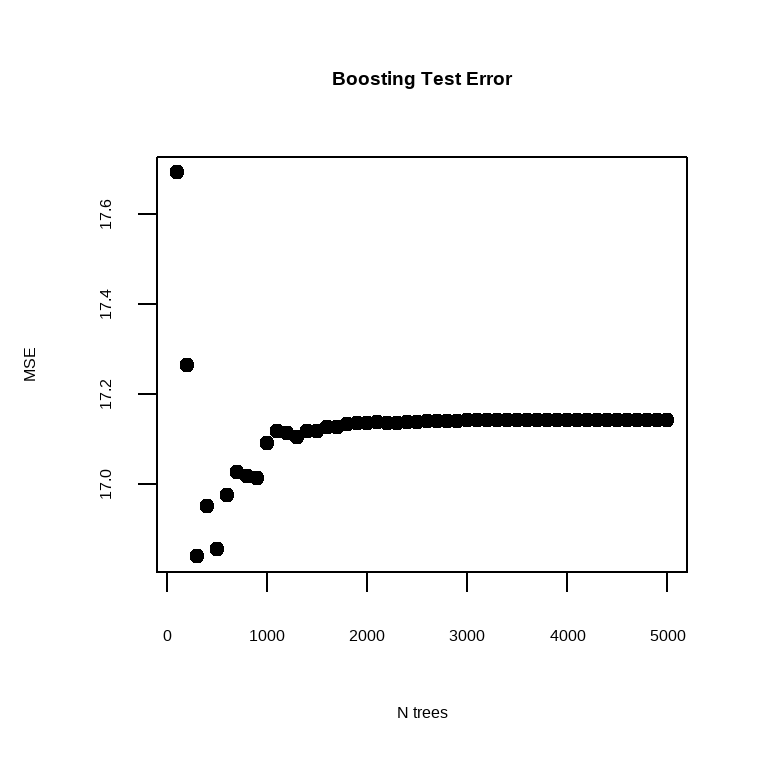

```r
plot(n_trees, err, pch=19, ylab="MSE", xlab="N trees", main= "Boosting Test Error")
```

let’s do cross validation:

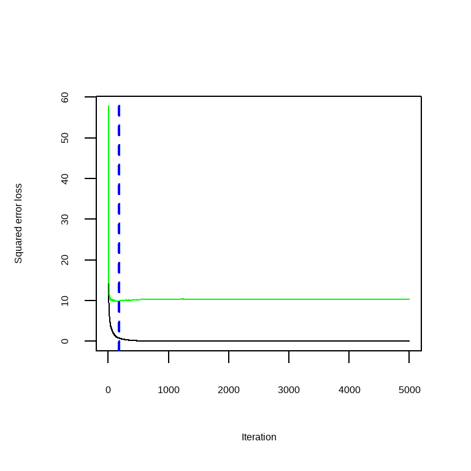

```r
#cross-validation
boston.boost.cv <- gbm(medv~., data = Boston[train,],
  distribution = "gaussian", n.trees=5000,
  interaction.depth=4, shrinkage = 0.2, verbose=F, cv.folds=10)


#find the best prediction
bestTreeForPrediction <- gbm.perf(boston.boost.cv)
```

we now predict using this tree:

```r
yhat.boost = predict(boston.boost.cv, newdata = Boston[-train,],n.trees = bestTreeForPrediction)
round(mean((yhat.boost-boston.test)^2),2)
```

```
[1] 19.05
```

Classification with Boosting

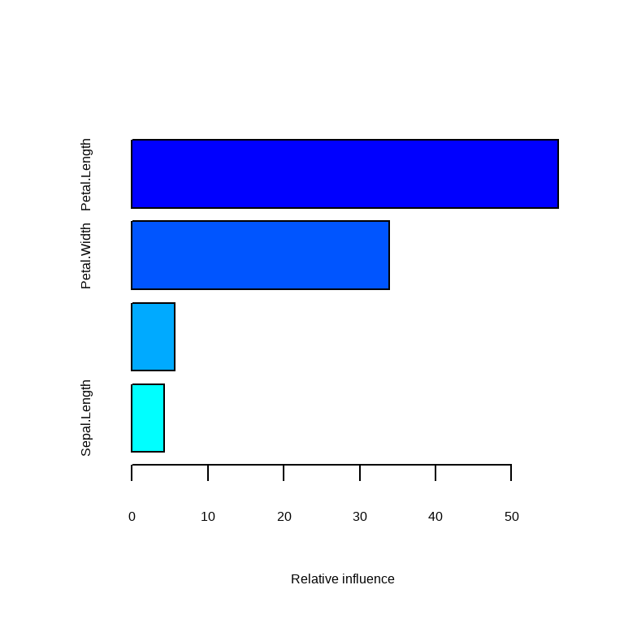

```
                      var   rel.inf
Petal.Length Petal.Length 56.150324
Petal.Width   Petal.Width 33.938916
Sepal.Width   Sepal.Width  5.621333
Sepal.Length Sepal.Length  4.289426
```

```r
# Train a boosting model
gbm_model <- gbm(Species ~ .,
  data = trainData,
  distribution = "multinomial",
  n.trees = 100,
  interaction.depth = 3,
  shrinkage = 0.1,
  cv.folds = 5)
summary(gbm_model)
```

To evaluate our model let’s test it in our test set:

```r
# Make predictions on the test set
gbm_pred <- predict(gbm_model,
  newdata = testData,
  n.trees = 100,
  type = "response")
gbm_pred_class <- colnames(gbm_pred)[apply(gbm_pred, 1, which.max)]

# Confusion matrix
boost_reg_conf_mat = caret::confusionMatrix(factor(gbm_pred_class), testData$Species)
boost_reg_conf_mat
```

```
Confusion Matrix and Statistics

            Reference
Prediction   setosa versicolor virginica
  setosa         16          0         0
  versicolor      0         16         0
  virginica       0          1        12

Overall Statistics

               Accuracy : 0.9778
                 95% CI : (0.8823, 0.9994)
    No Information Rate : 0.3778
    P-Value [Acc > NIR] : < 0.00000000000000022

                  Kappa : 0.9664

 Mcnemar's Test P-Value : NA

Statistics by Class:

                     Class: setosa Class: versicolor Class: virginica
Sensitivity                 1.0000            0.9412           1.0000
Specificity                 1.0000            1.0000           0.9697
Pos Pred Value              1.0000            1.0000           0.9231
Neg Pred Value              1.0000            0.9655           1.0000
Prevalence                  0.3556            0.3778           0.2667
Detection Rate              0.3556            0.3556           0.2667
Detection Prevalence        0.3556            0.3556           0.2889
Balanced Accuracy           1.0000            0.9706           0.9848
```

For each species:

```r
boost_reg_conf_mat$byClass
```

```
                  Sensitivity Specificity Pos Pred Value Neg Pred Value
Class: setosa       1.0000000    1.000000      1.0000000      1.0000000
Class: versicolor   0.9411765    1.000000      1.0000000      0.9655172
Class: virginica    1.0000000    0.969697      0.9230769      1.0000000
                  Precision    Recall       F1 Prevalence Detection Rate
Class: setosa     1.0000000 1.0000000 1.000000  0.3555556      0.3555556
Class: versicolor 1.0000000 0.9411765 0.969697  0.3777778      0.3555556
Class: virginica  0.9230769 1.0000000 0.960000  0.2666667      0.2666667
                  Detection Prevalence Balanced Accuracy
Class: setosa                0.3555556         1.0000000
Class: versicolor            0.3555556         0.9705882
Class: virginica             0.2888889         0.9848485
```

# 7 Bayesian Additive Regression Trees (BART)

Bart is related to both random forest and boosting: each tree is constructed in a random manner as in bagging and random forest, and each tree tries to capture signal not yet accounted for by the current model, as in boosting. The main novelty in BART is the way in which new trees are generated. BART can be applied to regression, classification and other problems.

All the different trees are built in parallel, and constructed like in boosting, where each step in each tree takes care of the residuals of the previous step, the difference here is that we apply a perturbance to each tree, so in step 2, each tree will have to deal with different parameters for example, or we grow a branch in one, but remove an existing branch in another tree.

K denote the number of regression trees and B the number of iterations or steps for which the BART algorithm will be run. The prediction at $x$ for the $kth$ regression tree used in the $bth$ iteration $\hat f^b_k(x)$. At the end of each iteration the K trees from that iteration will be summed i.e

$$\hat f^b_k(x) = \sum^K_{k=1}\hat f^b_k(x) \ for \ b=1,\dots,B$$
In the first iteration, all trees are initialized to have a single root node and the predictions will be just the average of the observations in all trees:

$$\hat f^b_k(x) = \sum^K_{k=1}\hat f^1_k(x) = \frac{1}{n}\sum^n_{i=1} y_1$$

In subsequent iterations, BART updates each of the K trees, one at a time. In the bth iteration, to update the kth tree, we substract from each response value the predictions from all but the kth tree, in order to obtain a *partial residual*
$$r_i = y_i - \sum_{k'<k}\hat f^{b-1}_k`(x_i) - \sum _{k`<k}\hat f^{b-1}_{k'}(x_i)$$
and then we create a tree over the partial residual but using a perturbation from a set of possible perturbations. The output of BART is a collection of prediction models. To obtain a single prediction, we simply take the average after some L *burn-in iterations* (we discard some of the initial iterations and calculate only based on later trees).

When we apply BART we must select the number of trees K, the number of iterations (B) and the number of burn-in iterations. We typically choose large values for B and K and a moderate value for L.

The perturbation-style avoids overfitting so we can choose a big number of iterations without risk of overfitting to the training data.

In this section we use the `BART` package, and within it the `gbart()` function, to fit a Bayesian additive regression tree model to the `Boston` housing data set. The `gbart()` function is designed for quantitative outcome variables. For binary outcomes, `lbart()` and `pbart()` are available.

To run the `gbart()` function, we must first create matrices of predictors for the training and test data. We run BART with default settings.

```r
library(BART)
x <- Boston[, 1:12]
y <- Boston[, "medv"]
xtrain <- x[train, ]
ytrain <- y[train]
xtest <- x[-train, ]
ytest <- y[-train]
set.seed(1)
bartfit <- gbart(xtrain, ytrain, x.test = xtest)
```

[output not shown]

Next we compute the test error.

```r
yhat.bart <- bartfit$yhat.test.mean
mean((ytest - yhat.bart)^2)
```

```
[1] 15.94718
```

On this data set, the test error of BART is lower than the test error of random forests and boosting.

Now we can check how many times each variable appeared in the collection of trees.

```r
ord <- order(bartfit$varcount.mean, decreasing = T)
bartfit$varcount.mean[ord]
```

```
    nox   lstat     tax     rad      rm   indus    chas ptratio     age      zn
 22.952  21.329  21.250  20.781  19.890  19.825  19.051  18.976  18.274  15.952
    dis    crim
 14.457  11.007
```